# HW1-2

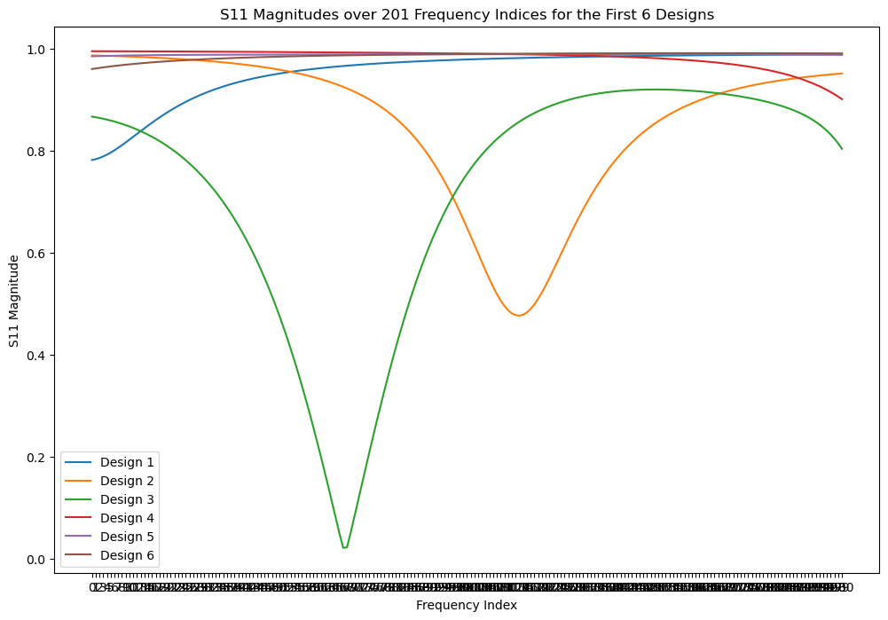

```python
import pandas as pd
import matplotlib.pyplot as plt
import numpy as np
# Load the input data
input_data = pd.read_csv('hw1_input.csv')

# Load the output data (real and imaginary parts of S11)
real_data = pd.read_csv('hw1_real.csv')
imag_data = pd.read_csv('hw1_img.csv')

# Calculate the magnitude of S11
s11_magnitude = (real_data**2 + imag_data**2)**0.5

# Plot the S11 magnitudes for the first 6 designs
plt.figure(figsize=(12, 8))
for i in range(6):
    plt.plot(s11_magnitude.iloc[i], label=f'Design {i+1}')

plt.xlabel('Frequency Index')
plt.ylabel('S11 Magnitude')
plt.title('S11 Magnitudes over 201 Frequency Indices for the First 6 Designs')
plt.legend()
plt.show()
```

```python
# Load the input data
input_data = pd.read_csv('hw1_input.csv')

# Load the output data (real and imaginary parts of S11)
real_data = pd.read_csv('hw1_real.csv')
imag_data = pd.read_csv('hw1_img.csv')

print(input_data.head())
print(real_data.head())
print(imag_data.head())
```

```
   length of patch  width of patch  height of patch  height of substrate  \
0         3.202024        2.288742         0.012514             0.139247
1         2.107848        2.895504         0.037171             0.149492
2         3.252113        4.818411         0.025432             0.578834
3         4.161509        2.294309         0.011058             0.117266
4         4.820912        2.948325         0.019658             0.163503

   height of solder resist layer  radius of the probe     c_pad  c_antipad  \
0                       0.041757             0.028566  0.000549   0.032403
1                       0.056775             0.028930  0.005536   0.053647
2                       0.029972             0.030922  0.020274   0.049845
3                       0.093223             0.017604  0.001135   0.098610
4                       0.094337             0.025757  0.021725   0.072813

    c_probe  dielectric constant of substrate  \
```

[output cut: 56 more lines]

```python
from sklearn.decomposition import PCA
import matplotlib.pyplot as plt

# Standardize the data
from sklearn.preprocessing import StandardScaler
scaler = StandardScaler()
scaled_input = scaler.fit_transform(input_data)
```

Indeed, PCA will help reduce the complexity of the design space by identifying those important parameters that contribute the most to the S11 response of the antenna. Principal component analysis works on the original design parameters in order to transform them into a minimal set of uncorrelated variables, called principal components (PCs), such that the first few PCs capture the maximum amount of variance in the data. Concentrating on the most meaningful principal components often simplifies the analysis and gives a more intuitive understanding of hidden patterns in the data.

Before applying PCA, the input data is standardized using StandardScaler. This ensures that all features contribute equally to the PCA, as they are scaled to have a mean of 0 and a standard deviation of 1.

```python
# Perform PCA to retain all components initially
pca = PCA()
principal_components = pca.fit_transform(scaled_input)
explained_variance_ratio = pca.explained_variance_ratio_

# Calculate the cumulative explained variance
cumulative_variance = np.cumsum(explained_variance_ratio)

# Find the number of components that explain at least 80% of the variance
num_components = np.argmax(cumulative_variance >= 0.80) + 1

print(f"Number of components that explain at least 80% of the variance: {num_components}")
```

```
Number of components that explain at least 80% of the variance: 8
```

The PCA is applied to the standardized data. Initially, all principal components are retained to analyze the explained variance. The cumulative explained variance is computed to determine the number of components that collectively explain at least 80% of the variance. In this case, 8 principal components were found to explain more than 80% of the total variance.

```python
# Reapply PCA with the determined number of components
pca = PCA(n_components=num_components)
principal_components = pca.fit_transform(scaled_input)
explained_variance_ratio = pca.explained_variance_ratio_
total_explained_variance = sum(explained_variance_ratio)
```

The magnitude of S11 values is calculated for each frequency. This plot visualizes the S11 magnitude across 201 frequency indices for the first six designs, highlighting patterns like resonance points. PCA is reapplied using only the top 8 components, as determined earlier. These components capture 86% of the total variance in the dataset, balancing dimensionality reduction with information retention.

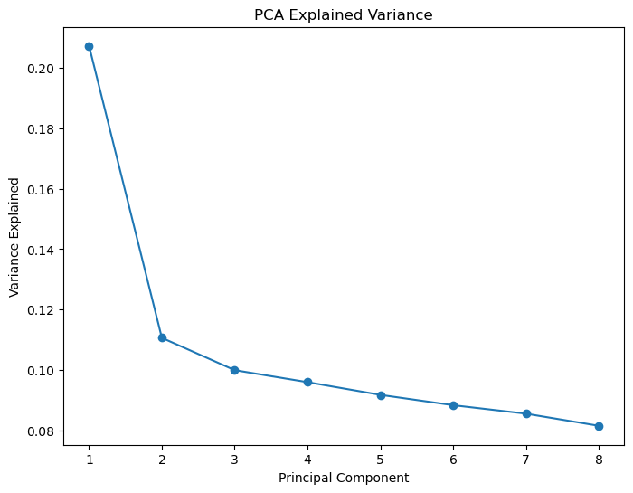

```
Explained Variance Ratio by Principal Components:
Principal Component 1: 0.2072
Principal Component 2: 0.1107
Principal Component 3: 0.1000
Principal Component 4: 0.0961
Principal Component 5: 0.0919
Principal Component 6: 0.0885
Principal Component 7: 0.0857
Principal Component 8: 0.0817
Total Variance Explained by 8 Principal Components: 0.8616
```

```python
# Plot the explained variance
plt.figure(figsize=(8, 6))
plt.plot(range(1, len(explained_variance_ratio) + 1), explained_variance_ratio, marker='o')
plt.xlabel('Principal Component')
plt.ylabel('Variance Explained')
plt.title('PCA Explained Variance')
plt.show()

# Print the explained variance ratio
print("Explained Variance Ratio by Principal Components:")
for i, ratio in enumerate(explained_variance_ratio):
    print(f"Principal Component {i+1}: {ratio:.4f}")

print(f"Total Variance Explained by {num_components} Principal Components: {total_explained_variance:.4f}")
```

The explained variance ratio for each principal component is plotted. This visual helps understand how much variance each component contributes, with the first few components explaining most of the variance.

```python
# Add principal components to the dataframe
pca_df = pd.DataFrame(data=principal_components, columns=[f'PC{i+1}' for i in range(principal_components.shape[1])])
```

```python
explained_variance_ratio = pca.explained_variance_ratio_
explained_variance_ratio
```

```
array([0.20715348, 0.11070825, 0.10003384, 0.09607237, 0.09187079,
       0.08845826, 0.08565904, 0.08165053])
```

PC1 explains about 20.7% of the variance. PC2 explains about 11.1% of the variance. PC3 explains about 10.0% of the variance. PC4 explains about 9.6% of the variance. Together, the first four principal components explain approximately 51.5% of the total variance. This suggests that these components capture the most critical aspects of the design space.

```python
total_variance_explained = sum(explained_variance_ratio)
print(f'Total Variance Explained by {num_components} Principal Components: {total_variance_explained:.2f}')
```

```
Total Variance Explained by 8 Principal Components: 0.86
```

The explained variance ratio for each of the top 8 components is printed, along with the total variance explained. These values quantify the information captured by each principal component and validate the effectiveness of the dimensionality reduction.

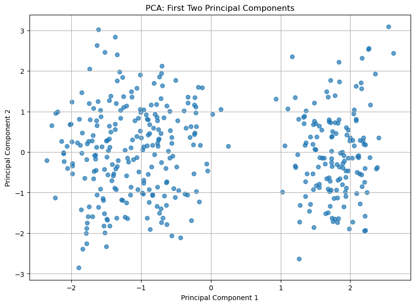

```python
plt.figure(figsize=(10, 7))
plt.scatter(pca_df['PC1'], pca_df['PC2'], alpha=0.7)
plt.xlabel('Principal Component 1')
plt.ylabel('Principal Component 2')
plt.title('PCA: First Two Principal Components')
plt.grid(True)
plt.show()
```

The analysis of the loadings, or coefficients, of the original design parameters onto each principal component will provide useful information with respect to the geometry-electromagnetic behavior relationship. For example, if a design parameter has a high loading in the first principal component PC1, then this parameter is very important with respect to explaining the variance captured by PC1. This then exposes which of the geometric features-length, angles, or any other design features-most greatly affect the S11 response of the antenna.

The ability to determine these key parameters through PCA helps us to focus on the most influential parts of the antenna geometry that are essentially responsible for electromagnetic behavior. In fact, such insight will be quite useful in the process of optimization and performance enhancement of the antenna. Hence, PCA simplifies not only the design space but also allows a deeper understanding of how specific geometric features would affect the antenna's electromagnetic characteristics, most notably, the response of S11.

In other words, PCA decreases design space complexity by retaining major dimensions responsible for explaining most of the variance. By focusing on these principal components and looking at the loadings of the original parameters, we will be able to identify the influential geometric features responsible for determining most of the antenna's S11 response. These insights will contribute toward more effective design processes and may result in even better-optimized antenna structures.

```python
# Calculate the magnitude of S11
s11_magnitude = (real_data**2 + imag_data**2)**0.5


# Find the resonance frequencies where S11 magnitude approaches zero
resonance_frequencies = s11_magnitude.idxmin(axis=1)
```

```python
resonance_frequencies=resonance_frequencies.astype(int)
resonance_frequencies
```

```
0        0
1      114
2       67
3      200
4        0
      ...
380    160
381     21
382      0
383    124
384    111
Length: 385, dtype: int64
```

[figure not shown]

[output not shown]

```python
# Plot the S11 magnitudes for the first 6 designs to visualize resonance frequencies
plt.figure(figsize=(12, 8))
for i in range(8):
    plt.plot(s11_magnitude.iloc[i], label=f'Design {i+1}')
    plt.scatter(resonance_frequencies[i], s11_magnitude.iloc[i, resonance_frequencies[i]], color='red')

plt.xlabel('Frequency Index')
plt.ylabel('S11 Magnitude')
plt.title('S11 Magnitudes over 201 Frequency Indices for the First 6 Designs')
plt.legend()
plt.show()

# Print the resonance frequencies for the first 6 designs
print("Resonance Frequencies (Frequency Indices) for the First 6 Designs:")
for i in range(8):
    print(f"Design {i+1}: {resonance_frequencies.iloc[i]}")
```

This plot illustrates the S11 magnitude for the first 8 designs across 201 frequency points. The red markers indicate the resonance frequencies where the S11 magnitude is minimal, providing insight into the antenna's performance.

The resonance frequency can be recognized by the frequency index where the S11 Magnitude has minimum values, meaning these are the points where the antenna is giving its best performance in terms of reflection. A function .idxmin(axis=1) gives the index along each row where the minimum value can be found. Such resonant frequencies will then be rounded into an integer for consistency. These are seen in detail in the following code: The multitarget nature of the analysis is reflected in that step, too. For each design, there may have been more than one frequency points considered, since in this regression task multiple resonance frequencies are considered as target variables. Thus, for each design, more than one values will be predicted, corresponding to real and imaginary components coming from the regression models.

```python
import numpy as np
import pandas as pd
import matplotlib.pyplot as plt
from sklearn.linear_model import LinearRegression
from sklearn.model_selection import train_test_split
from sklearn.metrics import mean_squared_error, r2_score
from sklearn.linear_model import LinearRegression
from sklearn.model_selection import train_test_split
from sklearn.metrics import mean_squared_error

# Select key frequency points resonance frequencies
key_freq_indices = resonance_frequencies.unique()
real_targets = real_data.iloc[:, key_freq_indices]
imag_targets = imag_data.iloc[:, key_freq_indices]

# Split the data into training and testing sets
X_train, X_test, y_train_real, y_test_real = train_test_split(input_data, real_targets, test_size=0.2, random_state=42)
_, _, y_train_imag, y_test_imag = train_test_split(input_data, imag_targets, test_size=0.2, random_state=42)

# Train linear regression models
real_model = LinearRegression()
imag_model = LinearRegression()

real_model.fit(X_train, y_train_real)
imag_model.fit(X_train, y_train_imag)

# Predict and evaluate the models
y_pred_real = real_model.predict(X_test)
y_pred_imag = imag_model.predict(X_test)

mse_real = mean_squared_error(y_test_real, y_pred_real)
mse_imag = mean_squared_error(y_test_imag, y_pred_imag)

print(f'Mean Squared Error for Real Part: {mse_real}')
print(f'Mean Squared Error for Imaginary Part: {mse_imag}')

r2_real = r2_score(y_test_real, y_pred_real)
r2_imag = r2_score(y_test_imag, y_pred_imag)
print(f'R^2 Score for Real Part: {r2_real}')
print(f'R^2 Score for Imaginary Part: {r2_imag}')
```

```
Mean Squared Error for Real Part: 0.08214103842631627
Mean Squared Error for Imaginary Part: 0.08613460099311021
R^2 Score for Real Part: 0.8168045230053144
R^2 Score for Imaginary Part: 0.1837859754507506
```

The next vital step towards improving model performance would, apart from selecting the appropriate model, be feature engineering. By the inclusion of more features or transformations, it can represent the imaginary S11 part to capture complex patterns. The interaction terms or polynomial features can model complex relationships in a better way. This is further enhanced by the incorporation of domain knowledge, like electrical properties or physical properties that affect S11, as additional features to enrich data representation and improve predictive accuracy.

PCA has been done, but other pre-processing steps scaling or normalization of features might be further used in order to enhance results from the model. This ensures that each feature contributes equally to the model, something rather important during regression tasks where features can be of a different order of magnitude. Besides, the employed method of dimensionality reduction, such as PCA, may also help to simplify information and reduce noise to just direct the model to the most informative ones.

It would be worth trying out, if the concern of model complexity is an issue, or overfitting in general, both Ridge and Lasso regression. These methods penalize large coefficients and lead to better generalization, avoiding overfitting. For more realistic performance evaluation, k-fold cross-validation may be done, allowing the model to predict completely unseen data, which can give a much better estimate of how well a model actually performs, and may indicate possible overfitting or underfitting and a better estimation of generalization.

```python
# Calculate the correlation matrix between design parameters and S11 magnitudes
correlation_matrix = pd.concat([input_data, s11_magnitude], axis=1).corr()
```

```python
# Select frequencies with high correlation to design parameters
correlation_with_design_params = correlation_matrix.iloc[:11, 11:]
high_correlation_indices = correlation_with_design_params.abs().mean(axis=0).sort_values(ascending=False).head(4).index

high_correlation_indices
```

```
Index(['57', '56', '55', '58'], dtype='object')
```

The correlation analysis helped to identify key frequency points that are most strongly related to the antenna design parameters. Initially, a correlation matrix was calculated between the design parameters and the S11 magnitudes. By examining this matrix, the frequencies with the highest correlation to the design parameters were selected. Specifically, the four frequency points with the highest average absolute correlation values were chosen: frequencies 57, 56, 55, and 58. These frequencies were identified as particularly significant in capturing the behavior of the S11 parameter, which allowed us to focus the regression task on these crucial points.

By selecting these high-correlation frequencies, the regression model could be simplified, focusing on the most critical aspects of the antenna's performance. This reduced the complexity of the multitarget regression approach, which would otherwise involve predictions across all 201 frequencies. As a result, the model could more effectively capture the relationship between the design parameters and the S11 values at the selected frequencies.

```python
from sklearn.linear_model import LinearRegression
from sklearn.model_selection import train_test_split
from sklearn.metrics import mean_squared_error, r2_score

# Split the data for high correlation frequencies
y_real_high_corr = real_data[high_correlation_indices]
y_imag_high_corr = imag_data[high_correlation_indices]

# Split the data into training and test sets
X_train, X_test, y_train_real, y_test_real = train_test_split(input_data, y_real_high_corr, test_size=0.2, random_state=42)
X_train, X_test, y_train_imag, y_test_imag = train_test_split(input_data, y_imag_high_corr, test_size=0.2, random_state=42)

# Train the regression model for the real part
regressor_real = LinearRegression()
regressor_real.fit(X_train, y_train_real)
y_pred_real = regressor_real.predict(X_test)

# Train the regression model for the imaginary part
regressor_imag = LinearRegression()
regressor_imag.fit(X_train, y_train_imag)
y_pred_imag = regressor_imag.predict(X_test)

# Calculate mean squared error (MSE) for real and imaginary parts
mse_real = mean_squared_error(y_test_real, y_pred_real)
mse_imag = mean_squared_error(y_test_imag, y_pred_imag)

print("MSE for the real part:", mse_real)
print("MSE for the imaginary part:", mse_imag)

r2_real = r2_score(y_test_real, y_pred_real)
r2_imag = r2_score(y_test_imag, y_pred_imag)
print("R^2 score for the real part:", r2_real)
print("R^2 score for the imaginary part:", r2_imag)
```

```
MSE for the real part: 0.08200739406235182
MSE for the imaginary part: 0.09895996292426164
R^2 score for the real part: 0.833161406072684
R^2 score for the imaginary part: 0.10709285992707701
```

Linear regression models were then trained on the real and imaginary parts of the S11 parameter at those selected frequencies. With an R² score of 0.83, the model was able to predict the real part successfully, showing that the geometric design parameters are strongly linearly related to the real component of S11. The MSE is 0.082, indicating the predictions made by the model are rather accurate. In contrast, the imaginary part of S11 was poorly represented with an R² and MSE value of 0.11 and 0.099, respectively, showing poor fitness of the linear regression model in capturing important relationships between the antenna design space and the imaginary part of S11. This may be attributed to more sophisticated nonlinear coupling that may take place.

When linear regression was applied on the individual frequency points, most especially the resonance frequencies, some interesting patterns in the results were unraveled. Most of the variation between the design parameters and the real part of S11 at these key frequencies could be quite well modeled, suggesting that the geometrical features are highly related to the real part of S11. The geometric features are likely to include something related to the shape, size, and orientation of the antenna, which influences how an antenna resonates at those types of frequencies.

On the other hand, the poor performance of the model about the imaginary component shows the more complex interaction between design parameters and the imaginary part of S11. It could also be that the imaginary part pertains to some nonlinear relationship or other factors not taken into consideration in this model. The pattern that emerges here suggests that though the real part of S11 is majorly dependent on the geometry of the antenna in a linear way, the imaginary part is more involving in factors that cannot be fully described by linear regression alone.

While the PCA and regression models are of great importance in the prediction of antenna performance, these methods play different roles, enjoying different strengths and weaknesses. Generally, PCA serves to reduce the dimensions by finding major principal components explaining most of the variance in the data. In the context of antenna performance, this would mean the reduction of a large number of design variables to a few uncorrelated components. It may subsequently be easier and more effective to carry out subsequent analyses. Among the advantages, PCA could reduce noise and collinearity in data, which may improve predictive model performance by filtering out only the most influential features in the model. Some of the limitations include the following:. Because, though it assumes linearity between the variables, which might not capture complex interactions, generally nonlinear in nature, and due to electromagnetic effects, especially in antenna performance. Also, the result components from PCA may not be physically bound, hence relating those to certain antenna design parameters may be hard to obtain.

Regression models, on the other hand, are designed to predict an outcome based on input variables. These models vary from the simplest, linear regression, to more complex ones such as polynomial regression, support vector machines, and neural networks. An immediate appeal with regression models is that one can model the relationship between the input features and the antenna performance metrics directly. Simple regression models are interpretable and provide clear insight into how individual features drive the outcome. However, there are also a number of disadvantages to simple regression models. The main limitation of typical regression models is that they usually assume linearity between variables-a rather pointless generalization considering the nonlinear electromagnetic behavior of antennas. Another serious drawback of these kinds of models is overfitting in cases of noisy data or when a model becomes overly complex. This occurs because the model learns the noise in the data rather than the true underlying pattern; hence, it generalizes poorly on new data.

With the complication in nonlinear behavior of antennas, both PCA and regression models can fail to represent their behaviors faithfully. While PCA is suffered from its own linearity assumption and the loss of physical interpretability within its components, the regression models can be promptly overfitted or could not capture nonlinearities that inherently exist in electromagnetic interaction. In this context, alternative methods can be employed. Nonlinear behaviors can be approached with techniques like a kernel PCA that can manage nonlinear relationships, or more advanced models from machine learning, such as neural networks. The models mentioned can model the complicated electromagnetic phenomena much better. Other potential improvements could be the application of regularization techniques to regression models, including Ridge or Lasso regression, which impose a penalty on overfitting by punitive measures taken against overly complex models. Where data is limited or noisy, further improvements would come from data augmentation, better feature selection strategies, and informing the model using domain knowledge.

While PCA is powerful for reducing large datasets, the principal components it identifies are often physically meaningless, with interpretation of results thus more cumbersome. In general, hybrid approaches-like domain-specific analysis in addition to PCA-may be applied with the aim of relating the components back to physical parameters of antennas. The same could be said about complex regression models, such as neural networks, which can handle nonlinear relationships but easily turn into black boxes that are not transparent. XAI techniques such as SHAP or LIME could be applied to such models for improved understanding of how individual features influence the predicted performance of the antenna.

Both PCA and regression models provide the useful tools for antenna performance prediction; in particular, both of them suffer from this limitation when dealing with complex nonlinear electromagnetic behaviors. Those can be further improved by enriching them with advanced techniques such as kernel methods, neural networks, or regularization strategies. For example, domain-knowledge or explainable-AI-enhanced interpretability of those models could ensure that they are not only accurate but also shed some light on the underlying physical processes.

Although I developed the methodology myself, I used chatGPT and course notes in the coding part.